# Statistique Exploratoire Multidimensionnelle

Vincent LE MEUR

2023-10-06

# Travaux pratiques d’Analyse Factorielle des Correspondances (AFC) sous R à l’aide de données « Contacts-Médias »

# PARTIE 1

#### On considère dans cette première partie que les modalités de l’âge et du niveau d’étude (Education) sont mises en modalités illustratives (supplémentaires) : c’est-à-dire qu’elles ne sont pas utilisées pour le calcul des valeurs propres mais qu’elles peuvent être utilisées pour l’interprétation des résultats.

#### Pour commencer on fait en sorte que le nom des lignes corresponde aux IND:

|  | radio | Tél. | QuotN | QuotR | PMag | PMTV |
| --- | --- | --- | --- | --- | --- | --- |
| AGRI | 96 | 118 | 2 | 71 | 50 | 17 |
| PEPA | 122 | 136 | 11 | 76 | 49 | 41 |
| PRCS | 193 | 184 | 74 | 63 | 103 | 79 |
| PRIN | 360 | 365 | 63 | 145 | 141 | 184 |
| EMPL | 511 | 593 | 57 | 217 | 172 | 306 |
| OUQU | 385 | 457 | 42 | 174 | 104 | 220 |

#### Ensuite on affiche le summary:

|  | radio | Tél. | QuotN | QuotR | PMag | PMTV |
| --- | --- | --- | --- | --- | --- | --- |
|  | Min. : 96.0 | Min. : 118.0 | Min. : 2.00 | Min. : 63.0 | Min. : 42.0 | Min. : 17.0 |
|  | 1st Qu.: 372.5 | 1st Qu.: 411.0 | 1st Qu.: 60.00 | 1st Qu.:142.5 | 1st Qu.:122.5 | 1st Qu.:202.0 |
|  | Median : 619.0 | Median : 719.0 | Median : 74.00 | Median :217.0 | Median :251.0 | Median :306.0 |
|  | Mean : 694.1 | Mean : 834.8 | Mean : 92.05 | Mean :337.0 | Mean :274.5 | Mean :360.8 |
|  | 3rd Qu.: 894.5 | 3rd Qu.:1021.5 | 3rd Qu.:118.50 | 3rd Qu.:418.5 | 3rd Qu.:340.5 | 3rd Qu.:480.0 |
|  | Max. :1667.0 | Max. :2063.0 | Max. :285.00 | Max. :854.0 | Max. :683.0 | Max. :938.0 |

## Méthode AFC:

```r
etude1.ca = CA(etude,row.sup=11:19, ncp=4, graph=FALSE)
```

### Tableau des valeurs propres :

|  | eigenvalue | percentage of variance | cumulative percentage of variance |
| --- | --- | --- | --- |
| dim 1 | 0.0084013 | 61.6276136 | 61.62761 |
| dim 2 | 0.0038427 | 28.1882165 | 89.81583 |
| dim 3 | 0.0009397 | 6.8931601 | 96.70899 |
| dim 4 | 0.0003927 | 2.8805823 | 99.58957 |
| dim 5 | 0.0000560 | 0.4104275 | 100.00000 |

### Axe à retenir:

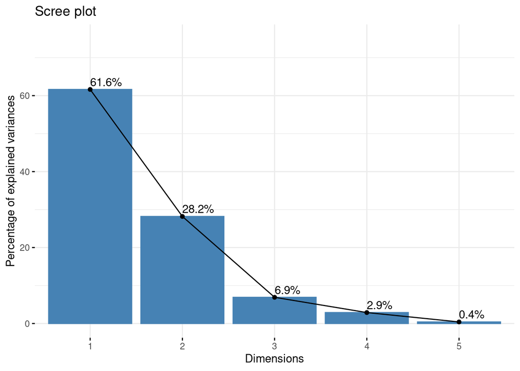

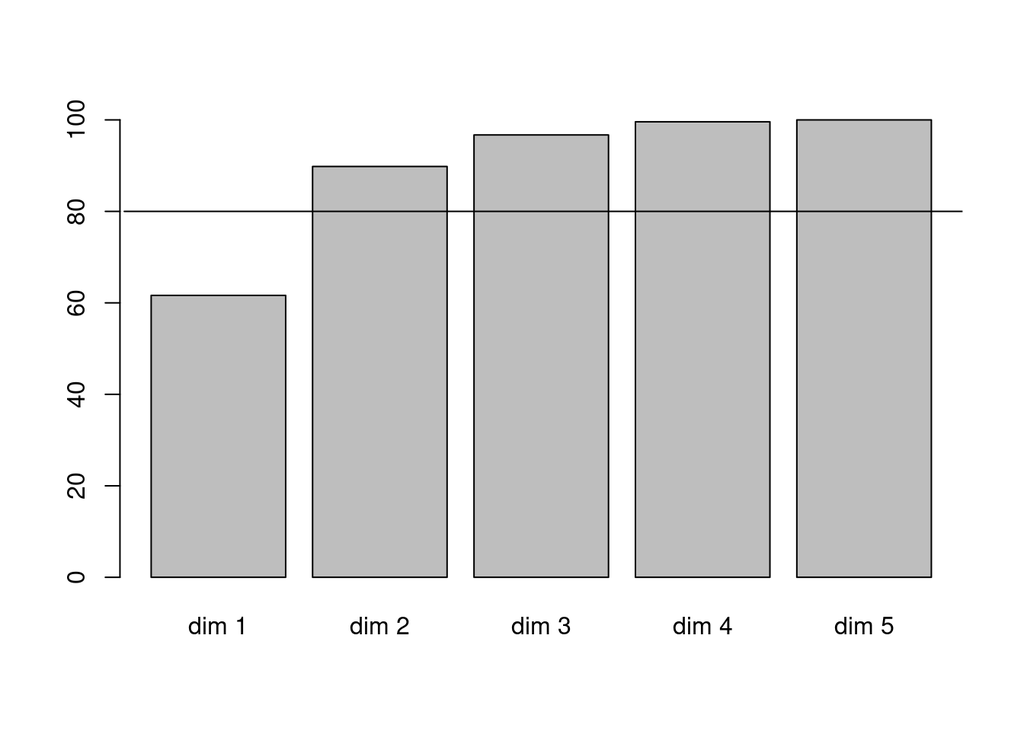

#### On remarque qu’on peut retenir 2 axes factoriels car à partir de cette dimension on observe un pourcentage de variance cumulé des valeurs propres de 90%. On l’observe de même avec le phénomène du coude qui est observable sur le premier graphique.

## Interprétation des axes en fonction des médias:

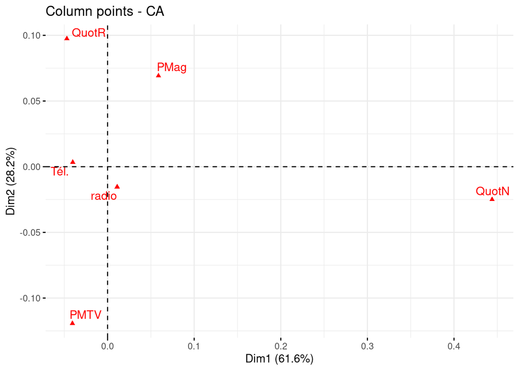

Tableau des signes

|  | Dim 1 | Dim 2 | Dim 3 | Dim 4 |
| --- | --- | --- | --- | --- |
| radio | 1 | -1 | -1 | -1 |
| Tél. | -1 | 1 | -1 | 1 |
| QuotN | 1 | -1 | -1 | 1 |
| QuotR | -1 | 1 | -1 | 1 |
| PMag | 1 | 1 | 1 | -1 |
| PMTV | -1 | -1 | 1 | 1 |

Tableau des contributions

|  | Dim 1 | Dim 2 | Dim 3 | Dim 4 |
| --- | --- | --- | --- | --- |
| radio | 0.3888974 | 1.6290520 | 3.9930710 | 67.2875072 |
| Tél. | 6.1568493 | 0.0954201 | 0.3000587 | 13.6758684 |
| QuotN | 82.8692769 | 0.5761167 | 6.2059846 | 6.7868145 |
| QuotR | 3.5421755 | 33.2871186 | 16.5799577 | 4.2889817 |
| PMag | 4.3287756 | 13.0954941 | 70.4927278 | 0.2030595 |
| PMTV | 2.7140253 | 51.3167984 | 2.4282003 | 7.7577687 |

Tableau des cos²

|  | Dim 1 | Dim 2 | Dim 3 | Dim 4 |
| --- | --- | --- | --- | --- |
| radio | 0.0822830 | 0.1576531 | 0.0944986 | 0.6654488 |
| Tél. | 0.8561516 | 0.0060691 | 0.0046670 | 0.0888898 |
| QuotN | 0.9848464 | 0.0031317 | 0.0082495 | 0.0037700 |
| QuotR | 0.1685580 | 0.7245158 | 0.0882482 | 0.0095398 |
| PMag | 0.2375595 | 0.3287164 | 0.4327077 | 0.0005209 |
| PMTV | 0.1006444 | 0.8704174 | 0.0100717 | 0.0134468 |

Tableau des coordonnées

|  | Dim 1 | Dim 2 | Dim 3 | Dim 4 |
| --- | --- | --- | --- | --- |
| radio | 0.0110789 | -0.0153353 | -0.0118728 | -0.0315064 |
| Tél. | -0.0401922 | 0.0033840 | -0.0029675 | 0.0129507 |
| QuotN | 0.4439626 | -0.0250352 | -0.0406328 | 0.0274685 |
| QuotR | -0.0470084 | 0.0974596 | -0.0340137 | 0.0111833 |
| PMag | 0.0587849 | 0.0691497 | 0.0793372 | -0.0027526 |
| PMTV | -0.0405920 | -0.1193738 | 0.0128409 | 0.0148373 |

#### Axe1:

##### L’axe 1 est principalement influencé par les variables QuotN et Tél. Cette conclusion est basée sur l’observation du graphique, où l’on peut clairement voir que QuotN et Tél expliquent bien cet axe. Cette tendance se confirme également au niveau du tableau des cos2, où ces deux médias sont les mieux représentés avec des cosinus carrés élevés. De plus, il est important de noter que Tél est en opposition avec le média QuotN, comme l’indique la différence de signes dans le tableau des signes. Cependant, c’est QuotN qui représente le mieux cet axe, avec une contribution notable de 82%. En somme, l’axe 1 est caractérisé par QuotN et Tél, avec une opposition entre ces deux médias, QuotN étant le plus prépondérant.

#### Axe2:

##### L’axe 2 est influencé par les variables QuotR, Pmag et PMTV. Cette conclusion est également basée sur l’observation du graphique, où l’on peut clairement voir que QuotR, Pmag et PMTV expliquent bien cet axe. Cette tendance se confirme au niveau du tableau des cos2, où ces trois médias sont les mieux représentés. En analysant les contributions, on constate que PMTV joue un rôle prépondérant en contribuant à hauteur de 51%, suivi de QuotR avec 33% et Pmag avec 13%. De plus, PMTV est en opposition avec les médias QuotR et Pmag, comme l’indique la différence de signes dans le tableau des signes. En résumé, l’axe 2 est principalement caractérisé par QuotR, Pmag et PMTV, avec une opposition marquée entre PMTV d’une part, et QuotR et Pmag d’autre part.

#### Synthèse :

##### Sur cet axe 1, les individus vont Enomément regarder le quotidient national et à l’inverse il vont peut être devant leur télévison.

##### Sur le 2 ème axe les individu présent vont regarder principalement le quotidien régional et la presse mazine et à l’inverse la presse mag.t.v.

## Interprétation des axes en fonction des modalités-lignes:

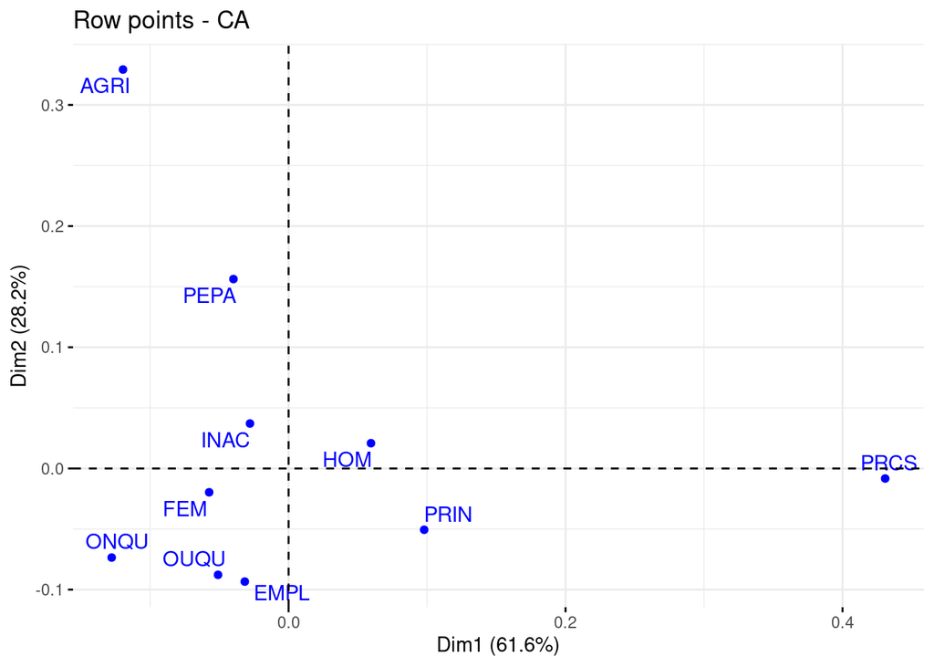

Tableau des signes

|  | Dim 1 | Dim 2 | Dim 3 | Dim 4 |
| --- | --- | --- | --- | --- |
| AGRI | -1 | 1 | 1 | -1 |
| PEPA | -1 | 1 | -1 | -1 |
| PRCS | 1 | -1 | 1 | -1 |
| PRIN | 1 | -1 | 1 | -1 |
| EMPL | -1 | -1 | 1 | -1 |
| OUQU | -1 | -1 | -1 | -1 |
| ONQU | -1 | -1 | -1 | -1 |
| INAC | -1 | 1 | 1 | 1 |
| HOM | 1 | 1 | -1 | 1 |
| FEM | -1 | -1 | 1 | -1 |

Tableau des contributions

|  | Dim 1 | Dim 2 | Dim 3 | Dim 4 |
| --- | --- | --- | --- | --- |
| AGRI | 2.4317338 | 40.3099352 | 0.5112176 | 20.9988461 |
| PEPA | 0.3312955 | 11.1645319 | 2.3221049 | 12.5659825 |
| PRCS | 62.0660981 | 0.0502915 | 9.4426462 | 0.1948249 |
| PRIN | 5.7964706 | 3.3834001 | 1.7810471 | 17.6619149 |
| EMPL | 0.8911880 | 16.9980545 | 0.0065474 | 1.8359793 |
| OUQU | 1.7228186 | 11.1917155 | 20.2803058 | 0.3401789 |
| ONQU | 4.2722479 | 3.0958735 | 3.5386243 | 7.0154644 |
| INAC | 2.1887444 | 8.4719182 | 1.5529617 | 37.6302192 |
| HOM | 10.3198001 | 2.7675134 | 30.7336123 | 0.8137623 |
| FEM | 9.9796031 | 2.5667661 | 29.8309327 | 0.9428275 |

Tableau des cos²

|  | Dim 1 | Dim 2 | Dim 3 | Dim 4 |
| --- | --- | --- | --- | --- |
| AGRI | 0.1107175 | 0.8394692 | 0.0026034 | 0.0446890 |
| PEPA | 0.0523189 | 0.8064474 | 0.0410174 | 0.0927566 |
| PRCS | 0.9807883 | 0.0003635 | 0.0166900 | 0.0001439 |
| PRIN | 0.6763994 | 0.1805865 | 0.0232465 | 0.0963346 |
| EMPL | 0.1016831 | 0.8870970 | 0.0000836 | 0.0097916 |
| OUQU | 0.1872979 | 0.5565219 | 0.2466101 | 0.0017286 |
| ONQU | 0.6527841 | 0.2163658 | 0.0604770 | 0.0501042 |
| INAC | 0.2736450 | 0.4844696 | 0.0217168 | 0.2199045 |
| HOM | 0.6846195 | 0.0839769 | 0.2280524 | 0.0025234 |
| FEM | 0.6864360 | 0.0807542 | 0.2295074 | 0.0030313 |

Tableau des coordonnées

|  | Dim 1 | Dim 2 | Dim 3 | Dim 4 |
| --- | --- | --- | --- | --- |
| AGRI | -0.1195666 | 0.3292336 | 0.0183348 | -0.0759630 |
| PEPA | -0.0398123 | 0.1563059 | -0.0352510 | -0.0530102 |
| PRCS | 0.4308005 | -0.0082936 | 0.0561975 | -0.0052182 |
| PRIN | 0.0979253 | -0.0505983 | 0.0181540 | -0.0369560 |
| EMPL | -0.0316118 | -0.0933706 | 0.0009062 | -0.0098096 |
| OUQU | -0.0509354 | -0.0877999 | -0.0584465 | -0.0048933 |
| ONQU | -0.1277273 | -0.0735348 | -0.0388771 | -0.0353864 |
| INAC | -0.0278759 | 0.0370909 | 0.0078529 | 0.0249892 |
| HOM | 0.0595029 | 0.0208398 | -0.0343424 | 0.0036125 |
| FEM | -0.0573351 | -0.0196654 | 0.0331527 | -0.0038101 |

## Analyse avec des lignes-modalités illustratives:

Tableaux des coords des lignes-modalités illustratives

|  | Dim 1 | Dim 2 | Dim 3 | Dim 4 |
| --- | --- | --- | --- | --- |
| AGE1 | -0.0083463 | -0.1087260 | 0.0446902 | -0.0571895 |
| AGE2 | 0.0082400 | -0.1265687 | 0.0105212 | -0.0204626 |
| AGE3 | 0.0286626 | -0.0170811 | -0.0002951 | -0.0107488 |
| AGE4 | -0.0028954 | 0.1071601 | -0.0296249 | 0.0094005 |
| AGE5 | -0.0400848 | 0.1495590 | -0.0227167 | 0.0852082 |
| PRIM | -0.1075969 | 0.1048289 | -0.0465443 | 0.0401925 |
| SECO | -0.0096921 | -0.0428925 | 0.0148501 | -0.0065490 |
| TECP | -0.0178367 | -0.2027027 | 0.1028213 | -0.0781027 |
| SUPE | 0.2838224 | -0.0324777 | 0.0562195 | -0.0236328 |

Tableaux des cos2 des lignes-modalités illustratives

|  | Dim 1 | Dim 2 | Dim 3 | Dim 4 |
| --- | --- | --- | --- | --- |
| AGE1 | 0.0038963 | 0.6612098 | 0.1117115 | 0.1829387 |
| AGE2 | 0.0040428 | 0.9538382 | 0.0065911 | 0.0249311 |
| AGE3 | 0.5395873 | 0.1916281 | 0.0000572 | 0.0758834 |
| AGE4 | 0.0006720 | 0.9204662 | 0.0703486 | 0.0070835 |
| AGE5 | 0.0504239 | 0.7019425 | 0.0161945 | 0.2278449 |
| PRIM | 0.4377568 | 0.4155231 | 0.0819155 | 0.0610835 |
| SECO | 0.0384514 | 0.7530799 | 0.0902684 | 0.0175559 |
| TECP | 0.0043219 | 0.5581629 | 0.1436176 | 0.0828654 |
| SUPE | 0.9417930 | 0.0123320 | 0.0369519 | 0.0065297 |

### Analyse:

##### On observe grace aux tableaux que la ligne-modalité illustatrive SUPE représente énormément la dimention une avec un cos2 de 0.94.

##### De même pour la dimension 2 les modalités AGE2 et AGE4 représente très bien cette dimension avec un cos2 de plus de 0.9 et sont suivi de SECO et AGE5 avec respectivement 0.75, 0.7. Deplus on observe que AGE4 et AGE5 sont en opposition avec AGE2 et SECO.

## Projection des modalités-lignes et des médias:

### Sans les illustratives:

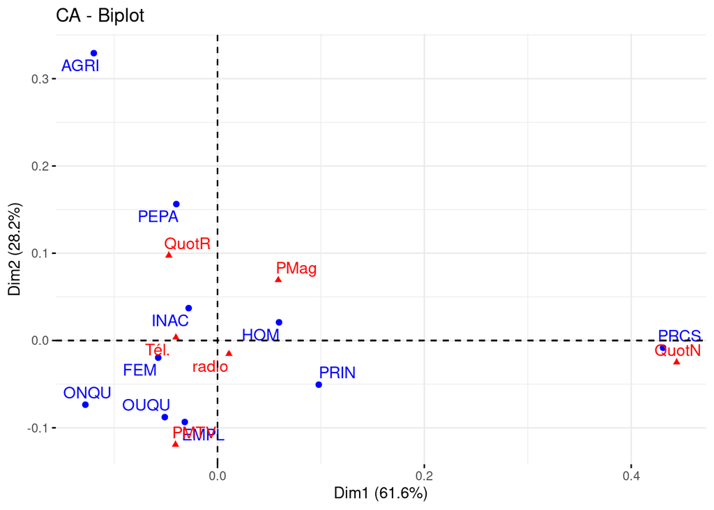

#### AXE1:

##### Sur cet axe on interprète que le quotidien national est surtout regardé par des cadres supérieurs et des profession liberal , cependant ces personnes vont beaucoup moins utiliser la télévision.

#### AXE2:

##### Sur cet axe, on obbserve que ce sont les médias du quotidien régional et la presse magazine ,qui sont surtout regardé par des agriculteurs mais aussi par des petits patrons. A l’inverse, ils ne vont pas regarder la presse Mag. T.V. et les employés ne vont pas regader ces médias.

### Avec les illustratives:

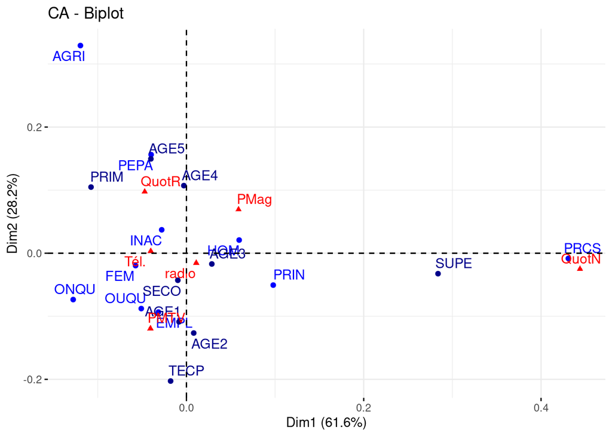

#### AXE1:

##### On peut rajouter à notre annalyse précédente qu’on à plusieurs personnes en étude superieur qui regardent beaucoup le quotidien national.

#### AXE2:

##### On peut rajouter de même à l’analyse précédente, entre 50 et + on tendance à regarder beacoup le quotidien régional ainsi que la presse magazine et à l’inverse peu la presse mag.t.v. Ainsi les personnes de 25 à 34 ans et les personnes danns un des etudes techn et prof ne regarde pas énormément le quotidien régional et la presse magazine.

## Rapport synthèse

#### Enfin, lors de la projection des modalités-lignes et des médias, nous observons que le Quotidien National est principalement regardé par des cadres supérieurs et des professionnels libéraux, tandis que le Quotidien Régional et la Presse Magazine sont populaires parmi les agriculteurs et les petits patrons. Les résultats sont plus détaillés avec les lignes-modalités illustratives, montrant, par exemple, que les personnes en études supérieures sont de grands consommateurs du Quotidien National, tandis que les personnes de 50 ans et plus sont davantage attirées par le Quotidien Régional et la Presse Magazine, avec des variations significatives en fonction de l’âge et du secteur d’études.

# Partie 2:

##### Maintenant on effectue l’AFC avec toutes les modalités-lignes et tous les médias.

## Méthode AFC:

```r
etude.ca = CA(etude, ncp=4, graph=FALSE)
```

### Tableau des valeurs propres :

|  | eigenvalue | percentage of variance | cumulative percentage of variance |
| --- | --- | --- | --- |
| dim 1 | 0.0114238 | 54.391621 | 54.39162 |
| dim 2 | 0.0077328 | 36.817591 | 91.20921 |
| dim 3 | 0.0010516 | 5.006956 | 96.21617 |
| dim 4 | 0.0004202 | 2.000487 | 98.21666 |
| dim 5 | 0.0003746 | 1.783345 | 100.00000 |

### Axe à retenir:

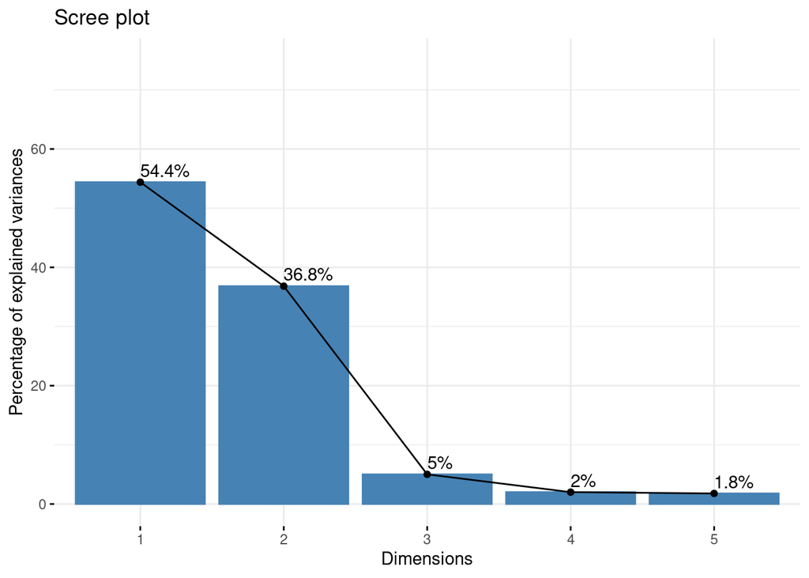

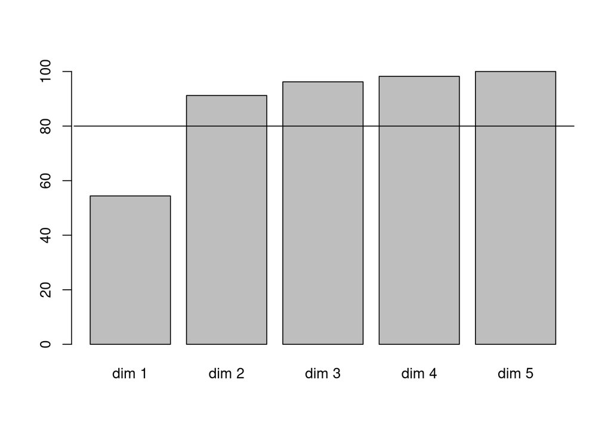

#### On remarque qu’on peut retenir encore 2 axes factoriels car à partir de cette dimension on observe un pourcentage de variance cumulé des valeurs propres de 90%. On l’observe de même avec le phénomène du coude qui est observable sur le premier graphique.

## Interprétation des axes en fonction des médias:

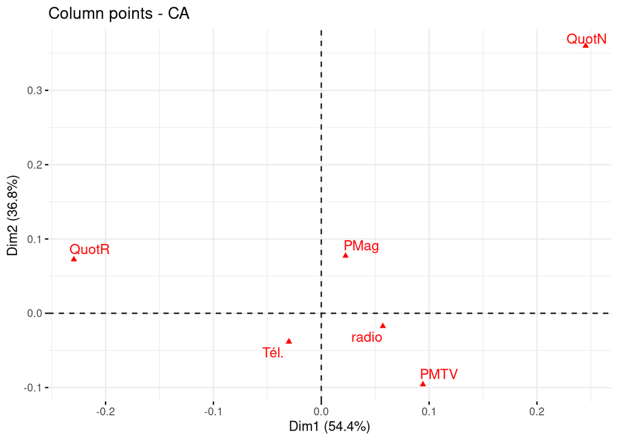

Tableau des signes

|  | Dim 1 | Dim 2 | Dim 3 | Dim 4 |
| --- | --- | --- | --- | --- |
| radio | 1 | -1 | -1 | -1 |
| Tél. | -1 | -1 | -1 | -1 |
| QuotN | 1 | 1 | 1 | 1 |
| QuotR | -1 | 1 | 1 | 1 |
| PMag | 1 | 1 | -1 | 1 |
| PMTV | 1 | -1 | 1 | 1 |

Tableau des contributions

|  | Dim 1 | Dim 2 | Dim 3 | Dim 4 |
| --- | --- | --- | --- | --- |
| radio | 7.6328640 | 1.065909 | 0.0935314 | 49.2637225 |
| Tél. | 2.5410357 | 6.065480 | 6.4267038 | 0.0000304 |
| QuotN | 18.6771465 | 59.397081 | 8.6551416 | 0.0096215 |
| QuotR | 59.8578628 | 8.799725 | 13.2843737 | 0.0662328 |
| PMag | 0.4688897 | 8.124827 | 45.1775414 | 21.4562170 |
| PMTV | 10.8222014 | 16.546979 | 26.3627082 | 29.2041758 |

Tableau des cos²

|  | Dim 1 | Dim 2 | Dim 3 | Dim 4 |
| --- | --- | --- | --- | --- |
| radio | 0.7151838 | 0.0676042 | 0.0008067 | 0.1697700 |
| Tél. | 0.2833218 | 0.4577810 | 0.0659628 | 0.0000001 |
| QuotN | 0.3112940 | 0.6701139 | 0.0132793 | 0.0000059 |
| QuotR | 0.8906954 | 0.0886340 | 0.0181966 | 0.0000362 |
| PMag | 0.0411971 | 0.4832076 | 0.3653933 | 0.0693351 |
| PMTV | 0.4222972 | 0.4370637 | 0.0946966 | 0.0419132 |

Tableau des coordonnées

|  | Dim 1 | Dim 2 | Dim 3 | Dim 4 |
| --- | --- | --- | --- | --- |
| radio | 0.0570791 | -0.0175491 | -0.0019170 | -0.0278099 |
| Tél. | -0.0300294 | -0.0381711 | -0.0144896 | -0.0000199 |
| QuotN | 0.2451696 | 0.3597125 | 0.0506372 | 0.0010672 |
| QuotR | -0.2293903 | 0.0723620 | 0.0327873 | 0.0014634 |
| PMag | 0.0224943 | 0.0770382 | -0.0669915 | 0.0291821 |
| PMTV | 0.0942603 | -0.0958941 | 0.0446361 | 0.0296958 |

#### Axe2:

##### L’axe 2 est influencé par les variables QuotN, PMTV. Cette conclusion est également basée sur l’observation du graphique, où l’on peut clairement voir que QuotN et PMTV expliquent bien cet axe. Cette tendance se confirme au niveau du tableau des cos2, où ces s médias sont bien représentés. En analysant les contributions, on constate que QuotN joue un rôle prépondérant en contribuant à hauteur de 59%, suivi de QPMTV avec 16.5%. De plus, PMTV est en opposition avec les médias QuotN, comme l’indique la différence de signes dans le tableau des signes. En résumé, l’axe 2 est principalement caractérisé par QuotN et PMTV, avec une opposition marquée entre PMTV d’une part, et QuotR d’autre part.

#### Synthèse:

##### Sur l’axe 1, La quotidien National est beaucoupo plus regardé que le régional.

##### Sur l’axe 2, ici ce sont les médias de la presse mag.t.v qui est peu regardé comparé au quotidien national.

## Interprétation des axes en fonction des modalités-lignes:

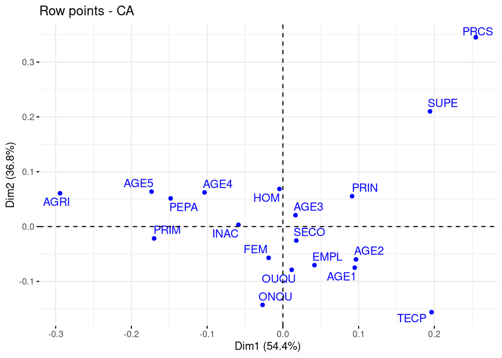

Tableau des signes

|  | Dim 1 | Dim 2 | Dim 3 | Dim 4 |
| --- | --- | --- | --- | --- |
| AGRI | -1 | 1 | -1 | -1 |
| PEPA | -1 | 1 | -1 | -1 |
| PRCS | 1 | 1 | -1 | 1 |
| PRIN | 1 | 1 | 1 | -1 |
| EMPL | 1 | -1 | 1 | 1 |
| OUQU | 1 | -1 | 1 | -1 |
| ONQU | -1 | -1 | 1 | -1 |
| INAC | -1 | 1 | -1 | 1 |
| HOM | -1 | 1 | 1 | -1 |
| FEM | -1 | -1 | -1 | 1 |
| AGE1 | 1 | -1 | -1 | -1 |
| AGE2 | 1 | -1 | 1 | 1 |
| AGE3 | 1 | 1 | 1 | -1 |
| AGE4 | -1 | 1 | -1 | -1 |
| AGE5 | -1 | 1 | -1 | 1 |
| PRIM | -1 | -1 | -1 | -1 |
| SECO | 1 | -1 | 1 | 1 |
| TECP | 1 | -1 | -1 | -1 |
| SUPE | 1 | 1 | -1 | 1 |

Tableau des contributions

|  | Dim 1 | Dim 2 | Dim 3 | Dim 4 |
| --- | --- | --- | --- | --- |
| AGRI | 5.4450876 | 0.3424655 | 21.9017348 | 11.7746357 |
| PEPA | 1.6972917 | 0.3019813 | 1.5601994 | 10.3273337 |
| PRCS | 8.0198946 | 21.7655178 | 0.9403917 | 0.3812135 |
| PRIN | 1.8664491 | 1.0112304 | 0.7832215 | 0.2360019 |
| EMPL | 0.5730182 | 2.4142680 | 6.5074246 | 0.4250786 |
| OUQU | 0.0329778 | 2.2570141 | 14.6795141 | 5.9882552 |
| ONQU | 0.0695133 | 2.9171360 | 1.5036050 | 4.9154873 |
| INAC | 3.5857364 | 0.0158379 | 1.0234662 | 10.9857636 |
| HOM | 0.0219791 | 7.5001733 | 7.0081358 | 13.2897397 |
| FEM | 0.3974722 | 5.3921810 | 1.8972812 | 13.6686582 |
| AGE1 | 3.5983614 | 3.3205051 | 0.3206773 | 1.0797197 |
| AGE2 | 3.7472646 | 2.1309766 | 6.8576864 | 0.0363205 |
| AGE3 | 0.1609231 | 0.3679151 | 2.5918796 | 0.0063729 |
| AGE4 | 4.5463678 | 2.4364525 | 0.9920289 | 5.3677863 |
| AGE5 | 11.8561896 | 2.3687079 | 1.0402318 | 13.1472781 |
| PRIM | 19.1296093 | 0.4579043 | 0.1972916 | 2.1610499 |
| SECO | 0.1794049 | 0.5461840 | 2.4291234 | 3.5631452 |
| TECP | 20.3489040 | 19.0012832 | 25.4641518 | 2.1462385 |
| SUPE | 14.7235555 | 25.4522661 | 2.3019547 | 0.4999217 |

Tableau des cos²

|  | Dim 1 | Dim 2 | Dim 3 | Dim 4 |
| --- | --- | --- | --- | --- |
| AGRI | 0.6393457 | 0.0272189 | 0.2367288 | 0.0508490 |
| PEPA | 0.6430563 | 0.0774454 | 0.0544145 | 0.1439078 |
| PRCS | 0.3498285 | 0.6426565 | 0.0037760 | 0.0006116 |
| PRIN | 0.6525125 | 0.2393019 | 0.0252057 | 0.0030345 |
| EMPL | 0.2023014 | 0.5769515 | 0.2114859 | 0.0055195 |
| OUQU | 0.0101108 | 0.4684061 | 0.4143033 | 0.0675257 |
| ONQU | 0.0294110 | 0.8354520 | 0.0585621 | 0.0764912 |
| INAC | 0.8735472 | 0.0026117 | 0.0229521 | 0.0984333 |
| HOM | 0.0034696 | 0.8014358 | 0.1018400 | 0.0771604 |
| FEM | 0.0789628 | 0.7251096 | 0.0346968 | 0.0998724 |
| AGE1 | 0.5915672 | 0.3695105 | 0.0048530 | 0.0065285 |
| AGE2 | 0.6429397 | 0.2474901 | 0.1083117 | 0.0002292 |
| AGE3 | 0.1898019 | 0.2937332 | 0.2814095 | 0.0002765 |
| AGE4 | 0.7008819 | 0.2542504 | 0.0140782 | 0.0304354 |
| AGE5 | 0.8252529 | 0.1116032 | 0.0066652 | 0.0336575 |
| PRIM | 0.9607121 | 0.0155663 | 0.0009121 | 0.0039917 |
| SECO | 0.1590269 | 0.3277168 | 0.1982109 | 0.1161645 |
| TECP | 0.5629916 | 0.3558502 | 0.0648533 | 0.0021839 |
| SUPE | 0.4574984 | 0.5353363 | 0.0065844 | 0.0005713 |

Tableau des coordonnées

|  | Dim 1 | Dim 2 | Dim 3 | Dim 4 |
| --- | --- | --- | --- | --- |
| AGRI | -0.2942436 | 0.0607120 | -0.1790460 | -0.0829813 |
| PEPA | -0.1481971 | 0.0514296 | -0.0431095 | -0.0701064 |
| PRCS | 0.2546748 | 0.3451817 | -0.0264592 | 0.0106485 |
| PRIN | 0.0913848 | 0.0553417 | 0.0179609 | -0.0062320 |
| EMPL | 0.0416871 | -0.0703998 | 0.0426229 | 0.0068858 |
| OUQU | 0.0115895 | -0.0788826 | 0.0741872 | -0.0299505 |
| ONQU | -0.0267943 | -0.1428065 | 0.0378090 | -0.0432109 |
| INAC | -0.0586776 | 0.0032084 | -0.0095113 | 0.0196970 |
| HOM | -0.0045161 | 0.0686361 | 0.0244668 | -0.0212968 |
| FEM | -0.0188178 | -0.0570243 | -0.0124739 | 0.0211632 |
| AGE1 | 0.0948363 | -0.0749524 | -0.0085897 | -0.0099628 |
| AGE2 | 0.0965004 | -0.0598719 | 0.0396079 | 0.0018220 |
| AGE3 | 0.0166740 | 0.0207427 | 0.0203029 | -0.0006364 |
| AGE4 | -0.1034543 | 0.0623099 | -0.0146622 | -0.0215584 |
| AGE5 | -0.1733813 | 0.0637598 | -0.0155817 | 0.0350146 |
| PRIM | -0.1700185 | -0.0216417 | -0.0052386 | -0.0109592 |
| SECO | 0.0177036 | -0.0254141 | 0.0197646 | 0.0151308 |
| TECP | 0.1963475 | -0.1561018 | -0.0666408 | -0.0122291 |
| SUPE | 0.1942658 | 0.2101430 | -0.0233055 | 0.0068650 |

#### Axe 2:

##### L’axe 2 est fortement influencé par les variables SUPE, TECP et PRCS ce qui peut être observé sur le graphique ainsi que grâce à leur contribution. Ces trois variables ont des cos² élevés, allant de 0,35 à 0,64, ce qui signifie qu’elles sont bien représentées sur cet axe. Il est également intéressant de noter que la variable TECP a des coordonnées négatives sur cet axe, ce qui est en opposition avec les 2 autres qui ont des coordonnées positives. En résumé, l’axe 2 est principalement caractérisé par TECP, SUPE et PRC.

#### Synthèse:

##### Pour l’axe 1, on observe que les individus en école primaire et entre 65 ans et + regardent pas dutout la même chose que les individus étant en études supérieurs et en Techn et prof.

##### Pour l’axe 2, on observe que les individus en étude tech et prof regardent des médias opposés aux indiviuds en études supérieurs et aux individus exercant une profession liberal ou des cadres supérieurs.

## Projection des modalités-lignes et des médias:

[figure not shown]